# **Examining Equity Across SDG 6.2.1a Progress in Thailand Using R and Tableau**

A. Malinish, M.S.

2023-01-10

## **Abstract**

Following the conclusion of the Millennium Development Goals (MDGs), the UN set forth the Sustainable Development Goals (SDGs) in 2015 to be adopted by all UN member countries, including Thailand (IMF, 2023). An environmental concern that Thailand has struggled with since the implementation of the UN’s MDGs and SDGs is access to sustainably managed water and water sanitation services (UN, n.d.; World, n.d.). The goal of this analysis was to examine Thailand’s reported progress on SDG 6.2.1a, the “proportion of population using safely managed sanitation services (UN, n.d.-a)”, to determine whether progress on the goal is equal across the country’s rural and urban regions. The results of this analysis revealed that SDG 6.2.1a attainment has been unequally observed between rural and urban regions, suggesting a potential disparity in access in sanitation services. Moreover, further examination of this relationship revealed the disparity between regions may be growing over time. For this reason, it is recommended that equitable access remains a key consideration for Thailand as the country continues to make progress on improving its water sources, availability, and sanitation services.

## **Introduction**

Following the conclusion of the Millennium Development Goals (MDGs) in 2015, the United Nations (UN) set forth the Sustainable Development Goals (SDGs) to be adopted by its member countries through 2030 (IMF, 2023). Broad in scope, the UN’s SDGs focus on five different areas: people, planet, peace, prosperity, and partnership (IMF, 2023). The goals also place additional emphasis on economic, social, and environmental sustainability (IMF, 2023).

This analysis will examine Thailand’s progress towards achieving the UN’s Sustainable Development Goals, specifically in relation to SDG 6. The overarching aim of SDG 6 is to ensure the availability and sustainable management of water and sanitation for all (UN, n.d.-b). Significant progress on this goal, as outlined by the Sustainable and Millennium Development Goals alike, has been challenging for Thailand (UN, n.d.; World, n.d.). Thailand’s Ministry of Health’s Report on Drinking Water Quality for 2009-2019 revealed that only 40.8% of available water was safe for consumption in households. The country’s population growth and increasing tourist numbers, coupled with inadequate drainage systems, have further exacerbated the issue of access to safe-to-consume drinking water (UN, n.d.-b). Despite the government’s efforts to achieve SDG 6, the percentage of poor-quality water sources doubled from 9% to 18% between 2018 and 2019 (UN, n.d.-b).

For the reasons discussed, this analysis will focus on Thailand’s progress towards achieving SDG 6.2.1a since the country’s adoption of the goal in 2015 (UN, n.d.-a). This particular indicator examines the “proportion of population using safely managed sanitation services (UN, n.d.-a)”. The data for SDG 6.2.1a is categorized by location type (rural or urban), which will allow additional insight into whether progress on the goal differs by location (WHO, 2023). Specifically, this analysis will test the hypothesis that use of sanitation services in Thailand is independent from location type (H0).

R will be used to extract, examine, and analyze SDG 6.2.1a data collected from the World Bank’s data repository for the Sustainable Development Goals (UN, n.d.-a; World, 2023). In addition to this, Tableau will be used to create additional graphical representations of the data (Figure 2).

## **Data Extraction**

The World Bank’s DataBank is a repository containing data from 261 countries across 85 different datasets (World, 2023). The Sustainable Development Goals’ database was accessed via the DataBank to acquire a subset of SDG 6.2.1a data from 2000-2020 (World, 2023). This information was downloaded in .csv format for analysis in R.

## **Methodology**

### R

Examination of the extracted dataset (World, 2023) revealed a makeup of 21 interval percentage variables (X2000..YR2000-X2020..YR2020) as well as four categorical variables (Country.Name, Country.Code, Series.Name, and Series.Code).

*Note: echo = FALSE used to hide R code chunk used to load required packages and data

```r
# DATA LOAD
summary(THA2000_2020)
```

```
##  Country.Name       Country.Code       Series.Name        Series.Code
##  Length:10          Length:10          Length:10          Length:10
##  Class :character   Class :character   Class :character   Class :character
##  Mode  :character   Mode  :character   Mode  :character   Mode  :character
##
##
##
##
##  X2000..YR2000.     X2001..YR2001.     X2002..YR2002.     X2003..YR2003.
##  Length:10          Length:10          Length:10          Length:10
##  Class :character   Class :character   Class :character   Class :character
##  Mode  :character   Mode  :character   Mode  :character   Mode  :character
##
##
##
##
##  X2004..YR2004.     X2005..YR2005.     X2006..YR2006.     X2007..YR2007.
##  Length:10          Length:10          Length:10          Length:10
##  Class :character   Class :character   Class :character   Class :character
##  Mode  :character   Mode  :character   Mode  :character   Mode  :character
##
##
##
##
##  X2008..YR2008.     X2009..YR2009.  X2010..YR2010.  X2011..YR2011.
##  Length:10          Min.   :19.75   Min.   :19.97   Min.   :20.20
##  Class :character   1st Qu.:21.20   1st Qu.:21.45   1st Qu.:21.71
##  Mode  :character   Median :22.65   Median :22.94   Median :23.23
##                     Mean   :22.65   Mean   :22.94   Mean   :23.23
##                     3rd Qu.:24.10   3rd Qu.:24.42   3rd Qu.:24.75
##                     Max.   :25.55   Max.   :25.90   Max.   :26.26
##                     NA's   :8       NA's   :8       NA's   :8
##  X2012..YR2012.  X2013..YR2013.  X2014..YR2014.  X2015..YR2015.
##  Min.   :20.42   Min.   :20.65   Min.   :20.87   Min.   :21.10
##  1st Qu.:21.97   1st Qu.:22.23   1st Qu.:22.49   1st Qu.:22.75
##  Median :23.52   Median :23.82   Median :24.11   Median :24.41
##  Mean   :23.52   Mean   :23.82   Mean   :24.11   Mean   :24.41
##  3rd Qu.:25.07   3rd Qu.:25.40   3rd Qu.:25.73   3rd Qu.:26.06
##  Max.   :26.62   Max.   :26.99   Max.   :27.35   Max.   :27.72
##  NA's   :8       NA's   :8       NA's   :8       NA's   :8
##  X2016..YR2016.  X2017..YR2017.  X2018..YR2018.  X2019..YR2019.
##  Min.   :21.33   Min.   :21.53   Min.   :21.74   Min.   :21.90
##  1st Qu.:23.02   1st Qu.:23.27   1st Qu.:23.51   1st Qu.:23.73
##  Median :24.71   Median :25.00   Median :25.29   Median :25.56
##  Mean   :24.71   Mean   :25.00   Mean   :25.29   Mean   :25.56
##  3rd Qu.:26.40   3rd Qu.:26.73   3rd Qu.:27.06   3rd Qu.:27.39
##  Max.   :28.09   Max.   :28.46   Max.   :28.84   Max.   :29.21
##  NA's   :8       NA's   :8       NA's   :8       NA's   :8
##  X2020..YR2020.
##  Min.   :22.07
##  1st Qu.:23.95
##  Median :25.82
##  Mean   :25.82
##  3rd Qu.:27.70
##  Max.   :29.58
##  NA's   :8
```

For the purpose of statistical analysis, the 21 interval variables were transformed to numeric and multiplied by 10 to represent count data in proportions of 1,000. Proportions of 1,000 (instead of 100) were used so that decimal point percentage changes could be observed. In addition to this, a “Location” column was added to the dataframe. Columns 5-19 (X2000..YR2000-X2014..YR2014) were removed since inspection of the data suggests that there is adequate data for the years 2015-2020. Rows 3-10 were also removed since they did not contain any relevant data on inspection.

```r
# TRANSFORMING VALUES

  # year values to numeric
THA2000_2020 <- THA2000_2020 %>% mutate_at(c('X2000..YR2000.','X2001..YR2001.','X2002..YR2002.','X2003..YR2003.',
                                             'X2004..YR2004.','X2005..YR2005.','X2006..YR2006.','X2007..YR2007.',
                                             'X2008..YR2008.','X2009..YR2009.','X2010..YR2010.','X2011..YR2011.',
                                             'X2012..YR2012.','X2013..YR2013.','X2014..YR2014.','X2015..YR2015.',
                                             'X2016..YR2016.','X2017..YR2017.','X2018..YR2018.','X2019..YR2019.',
                                             'X2020..YR2020.'), as.numeric)

  # multiply to replace percentage with counts*10
multiply <- function(x,y=10){
  x*y
}

THA2000_2020[1:2,5:25] <- multiply(THA2000_2020[1:2,5:25],)

  # add location column
THA2000_2020$Location <- c("RURAL", "URBAN")

#remove unnecessary columns and rows
THA2000_2020 <- THA2000_2020[,-c(5:19)]
THA2000_2020 <- THA2000_2020[-c(3,4,5,6,7,8,9,10), ]

head(THA2000_2020)
```

```
##   Country.Name Country.Code
## 1     Thailand          THA
## 2     Thailand          THA
##                                                                      Series.Name
## 1 People using safely managed sanitation services, rural (% of rural population)
## 2 People using safely managed sanitation services, urban (% of urban population)
##         Series.Code X2015..YR2015. X2016..YR2016. X2017..YR2017. X2018..YR2018.
## 1 SH.STA.SMSS.RU.ZS       211.0001       213.2554       215.3374       217.3747
## 2 SH.STA.SMSS.UR.ZS       277.1978       280.8984       284.6210       288.3656
##   X2019..YR2019. X2020..YR2020. Location
## 1       219.0120       220.6527    RURAL
## 2       292.1323       295.8436    URBAN
```

*Note: warning = FALSE used to suppress warnings about NAs generated by R code chunk

The dataframe “WITHOUT” was created to represent the proportion of population not using safely managed sanitation services. Columns in this dataframe mirrored the final selection of columns from the original dataframe (Country.Name, Country.Code, Series.Name, Series.Code, X2015..YR2015-X2020..YR2020, and Location). Values for Series.Name were set to “Not using safely managed sanitation services, rural” and “Not using safely managed sanitation services, urban” for the new dataframe. Meanwhile, counts for X2015..YR2015-X2020..YR2020 in the “WITHOUT” dataframe were calculated by creating and applying a subtraction function to X2015..YR2015-X2020..YR2020 values from the initial dataframe.

```r
  # creating dataframe for "Not using safely managed sanitation services"
WITHOUT <- data.frame(Country.Name = THA2000_2020$Country.Name, Country.Code = THA2000_2020$Country.Code,
                      Series.Name = c("Not using safely managed sanitation services, rural",
                                      "Not using safely managed sanitation services, urban"),
                      Series.Code = THA2000_2020$Series.Code,
                      THA2000_2020[,5:10],
                      Location = THA2000_2020$Location,
                      stringsAsFactors = FALSE)

  # creating counts for "Not using safely managed sanitation services"
subtract <- function(x=1000,y){
  x-y
}

WITHOUT[1:2,5:10] <- subtract(,WITHOUT[1:2,5:10])
WITHOUT
```

```
##   Country.Name Country.Code                                         Series.Name
## 1     Thailand          THA Not using safely managed sanitation services, rural
## 2     Thailand          THA Not using safely managed sanitation services, urban
##         Series.Code X2015..YR2015. X2016..YR2016. X2017..YR2017. X2018..YR2018.
## 1 SH.STA.SMSS.RU.ZS       788.9999       786.7446       784.6626       782.6253
## 2 SH.STA.SMSS.UR.ZS       722.8022       719.1016       715.3790       711.6344
##   X2019..YR2019. X2020..YR2020. Location
## 1       780.9880       779.3473    RURAL
## 2       707.8677       704.1564    URBAN
```

An additional dataframe (WITH-WITHOUT) was created to combine the two previous dataframes, accounting for counts of households using and not using safely managed sanitation services. The count data was also rounded to whole numbers and was sorted by location (RURAL, URBAN).

```r
# COMBINING DATAFRAMES

WITH_WITHOUT <- rbind(THA2000_2020, WITHOUT) %>%
  arrange(Location)

  # rounding count data
WITH_WITHOUT[1:4,5:10] <- round(WITH_WITHOUT[1:4,5:10], digits = 0)
WITH_WITHOUT
```

```
##   Country.Name Country.Code
## 1     Thailand          THA
## 2     Thailand          THA
## 3     Thailand          THA
## 4     Thailand          THA
##                                                                      Series.Name
## 1 People using safely managed sanitation services, rural (% of rural population)
## 2                            Not using safely managed sanitation services, rural
## 3 People using safely managed sanitation services, urban (% of urban population)
## 4                            Not using safely managed sanitation services, urban
##         Series.Code X2015..YR2015. X2016..YR2016. X2017..YR2017. X2018..YR2018.
## 1 SH.STA.SMSS.RU.ZS            211            213            215            217
## 2 SH.STA.SMSS.RU.ZS            789            787            785            783
## 3 SH.STA.SMSS.UR.ZS            277            281            285            288
## 4 SH.STA.SMSS.UR.ZS            723            719            715            712
##   X2019..YR2019. X2020..YR2020. Location
## 1            219            221    RURAL
## 2            781            779    RURAL
## 3            292            296    URBAN
## 4            708            704    URBAN
```

Examination of *WITH-WITHOUT* revealed five categorical predictor variables along with six numerical response variables. Of these variables, two related predictor variables appeared most relevant to the hypothesis in question – **Series.Name** and **Location**. Meanwhile, the six response variables all had one attribute in common – they were time indicators. The characteristics of *WITH-WITHOUT*, therefore, suggested that grouping, filtering, and restructuring was required for the variables of interest. A new dataframe, *COUNTS_LOC*, was created to perform the regrouping, restructuring, and filtering of data.

The first change made to *COUNTS_LOC* was removing **Country.Name**, **Country.Code**, and **Series.Code** from the dataframe since they were not needed for analysis. From there, *COUNTS_LOC* was restructured into long format in order to group the data by **Year**. The variable **Count** was also created to coincide with calculated counts for each category of **Series.Name** by **Location** and **Year**. The original values for **Year** (X2015..YR2015.:X2020..YR2020.) were also replaced with numeric values (2015:2020). Further examination of **Series.Name** made it apparent that the variable could be restructured into a binomial variable should the location portion of **Series.Name** be ignored, which was deemed appropriate given then presence of the variable **Location**. As a result, **Series.Name** was renamed **Use** with a binomial Yes/No value. The resulting dataframe from the changes made to *COUNTS_LOC* was saved as the R object *COUNTS_YRS_LOC*. This is the dataframe that will be used for hypothesis testing.

```r
COUNTS_LOC <- WITH_WITHOUT

COUNTS_LOC <- COUNTS_LOC[,-c(1,2,4)]

COUNTS_YRS_LOC <- gather(COUNTS_LOC, Year, Count, X2015..YR2015.:X2020..YR2020., factor_key=FALSE)

COUNTS_YRS_LOC$Series.Name <- rep(c("Yes","No"), 12)

COUNTS_YRS_LOC$Year <- c(rep(2015, 4),rep(2016, 4),rep(2017,4),rep(2018,4),rep(2019,4),rep(2020,4))

names(COUNTS_YRS_LOC)[names(COUNTS_YRS_LOC) == 'Series.Name'] <- 'Use'

COUNTS_YRS_LOC
```

```
##    Use Location Year Count
## 1  Yes    RURAL 2015   211
## 2   No    RURAL 2015   789
## 3  Yes    URBAN 2015   277
## 4   No    URBAN 2015   723
## 5  Yes    RURAL 2016   213
## 6   No    RURAL 2016   787
## 7  Yes    URBAN 2016   281
## 8   No    URBAN 2016   719
## 9  Yes    RURAL 2017   215
## 10  No    RURAL 2017   785
## 11 Yes    URBAN 2017   285
## 12  No    URBAN 2017   715
## 13 Yes    RURAL 2018   217
## 14  No    RURAL 2018   783
## 15 Yes    URBAN 2018   288
## 16  No    URBAN 2018   712
## 17 Yes    RURAL 2019   219
## 18  No    RURAL 2019   781
## 19 Yes    URBAN 2019   292
## 20  No    URBAN 2019   708
## 21 Yes    RURAL 2020   221
## 22  No    RURAL 2020   779
## 23 Yes    URBAN 2020   296
## 24  No    URBAN 2020   704
```

Given the presence of two binomial predictor variables (**Use** and **Location**) and a single ordinal predictor variable (**Year**) with a limited range, it was decided to treat **Year** as an additional categorical variable. The existence of multiple categorical/binomial predictor variables and a **Count** response variable made it apparent that the data was best suited for a non-parametric test.

Since the data contains repeated measures across multiple years, and therefore violates the independent observations assumption, multiple chi-square tests (for each year) were performed at once using the grouped_ggbarstats() function. Of note, McNemar’s chi-square test was considered, however was not chosen so that the relationship between urban and rural locations could be analyzed (versus the relationship between years).

The variable arguments for grouped_ggbarstats() were set as follows: X = **Location**, Y = **Use**, counts = **Count**, and grouping.var = **Year**. Additional arguments were used to combine the plots from each individual chi-square test into a single plot. The results from this R code chunk was stored as *CHI_LOC_YR*.

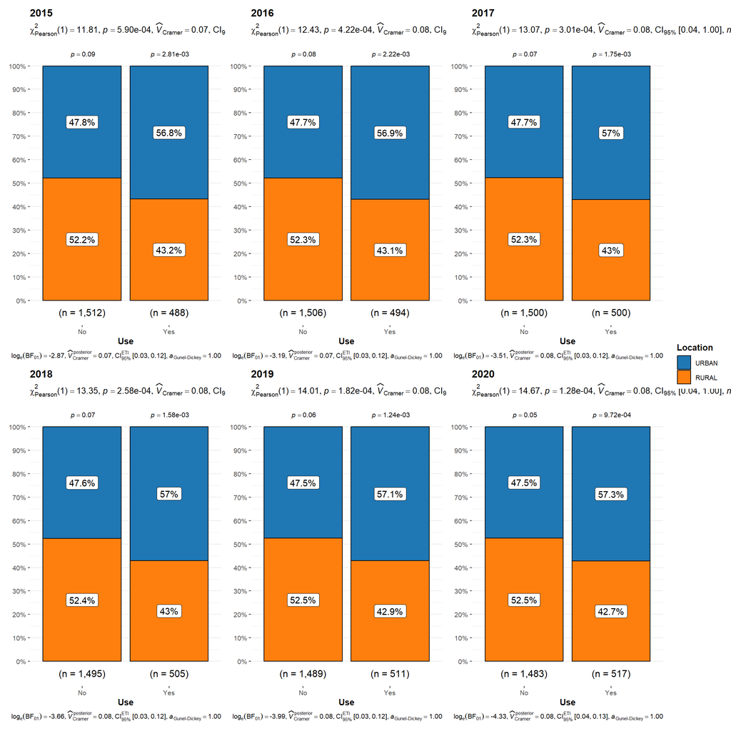

```r
## PERFORMING CHI-SQUARE TESTS

CHI_LOC_YR <- grouped_ggbarstats(
  #arguments required by ggbarstats()
  data = COUNTS_YRS_LOC,
  x = Location,
  y = Use,
  counts = Count,
  grouping.var = Year,
  perc.k = 1,
  package = "ggsci",
  palette = "category10_d3",
  # arguments relevant for `combine_plots()`
  title.text = "People using safely managed sanitation services by location and year",
  plotgrid.args = list(nrow = 2,ncol=3))
```

Figure 1. Chi-Square Distributions and Results by Year

*Note: echo = FALSE used to hide r code chunk used to plot Figure 1

### Tableau

To determine whether a trend exists between individual chi-square p-values, a line graph that plots the individual p-values against the **Year** variable was generated in Tableau. The dataframe *CHI_PVALS*, containing p-values and their corresponding years (extracted from *CHI_LOC_YR*), was created in R for import into Tableau. Once *CHI_PVALS* was imported into Tableau, **Year** was converted to a whole number value and **P.Value** into decimal format under the *Data Source* tab. A worksheet, with column = **Year** and row = **P.Value**, was created to generate a line graph of the data. The resulting graph (Figure 2) was then downloaded in .png format and embedded into this RMarkdown file.

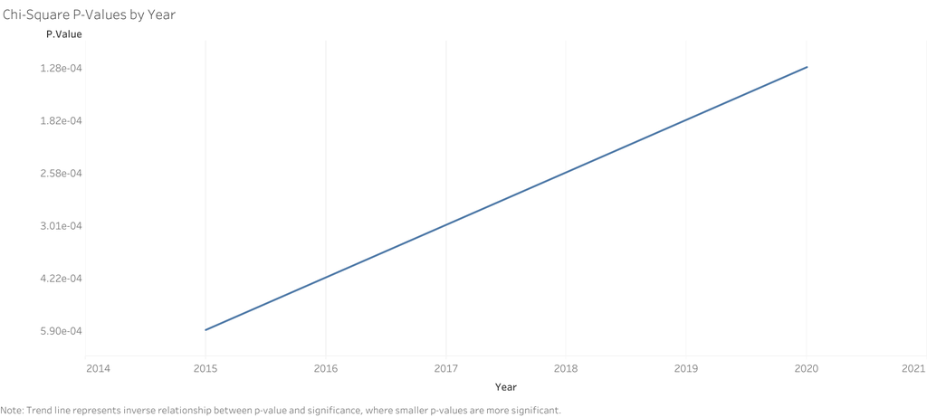

```r
CHI_PVALS <- data.frame(P.Value = c(CHI_LOC_YR[[1]][["labels"]][["subtitle"]][[3]][[3]],
                                   CHI_LOC_YR[[2]][["labels"]][["subtitle"]][[3]][[3]],
                                   CHI_LOC_YR[[3]][["labels"]][["subtitle"]][[3]][[3]],
                                   CHI_LOC_YR[[4]][["labels"]][["subtitle"]][[3]][[3]],
                                   CHI_LOC_YR[[5]][["labels"]][["subtitle"]][[3]][[3]],
                                   CHI_LOC_YR[[6]][["labels"]][["subtitle"]][[3]][[3]]),
                       Year = c(2015,2016,2017,2018,2019,2020),
                       stringsAsFactors = FALSE)

save(CHI_PVALS, file = "Chi_PVals_SDG6_2_1a.rdata")
```

Figure 2. Line graph plotting individual p-values from chi-square tests over the variable, *Year*

*Note: echo = FALSE used to hide R code chunk used to embed Tableau graphic

## **Results**

### Chi-Square Test for Independence

The results for each chi-square test are included at the top of each plot in Figure 1. By looking at the p-values for each test, we can see that each year from 2015 to 2020 produced a significant p-value. For this reason, we were able to reject the null hypothesis that **Location** is independent from **Use** across all years. In addition to this, we can also see that this relationship between the two variables appears to increase by year, with 2020 producing the most significant result among all years.

## **Discussion**

Overall, it is recommended that progress on SDG 6.2.1a is continuously monitored, with equitable access (as opposed to overall increased access) to sanitation services being a key consideration.

## **Limitations**

This analysis was limited due to the fact that raw counts of data on SDG 6.2.1a were not available for Thailand. As a result, this analysis had to rely on artificial counts that were generated by transforming proportions. For this reason, it was not appropriate to conduct power calculations during this analysis as such calculations would be based on artificial sample sizes.

Similarly, the linear trend observed in Figure 2 could not be tested for significance due to the small number of years observed.

## References

International Monetary Fund [IMF]. (2023). The IMF and the Sustainable Development Goals (SDG). International Monetary Fund. https://www.imf.org/en/About/Factsheets/Sheets/2023/IMF-Sustainable-development-goals-SDGs

Patil, I. (n.d.). Ggbarstats. GitHub. Retrieved January 5, 2023, from https://indrajeetpatil.github.io/ggstatsplot/articles/web_only/ggbarstats.html

United Nations [UN]. (n.d.-a). Global indicator framework for the Sustainable Development Goals and targets of the 2030 Agenda for Sustainable Development. United Nations. Retrieved January 5, 2023, from https://unstats.un.org/sdgs/indicators/Global%20Indicator%20Framework%20after%202023%20refinement_Eng.pdf

United Nations [UN]. (n.d.-b). Thailand: Achieving Progress on SDG 6. United Nations: Department of Economic and Social Affairs. Retrieved January 2, 2023, from https://sdgs.un.org/basic-page/thailand-34142

World Bank Group. (2023). Sustainable Development Goals (SDGs): DataBank. The World Bank: IBRD, IDA. https://databank.worldbank.org/source/sustainable-development-goals-(sdgs)

World Health Organization [WHO]. (n.d.). Millennium Development Goals (MDGs). Millennium Development Goals (MDGs). Retrieved January 5, 2023, from https://www.who.int/news-room/fact-sheets/detail/millennium-development-goals-(mdgs)